# Exploring my financial activity

Joshlynn Hilburn

## Introduction

As a recent college grad trying make sense of my finances, I started this project to analyze my past spending history. I want to see exactly what I use my money on and how I can better manage it. After bills, what do I spend my disposable income on and where should I cut back on to save money? Analyzing my history over the past six months, when I finally moved out of my parent’s house and started to support myself, will allow me to create a budget that accounts for everything

I downloaded my financial activity directly from my bank, University Federal Credit Union, which includes all data since I opened my account. The time period starts on Jan 17th, 2021 to Feb 2nd, 2022 which is roughly one year spending to analyze. The raw data is organized into 162 rows with 4 columns as a .CSV file and is free to access for personal use.

Data cleaning and processing was accomplished in Microsoft Excel and I documented the entire process which can be seen [here](http://joshlynnhilburn.github.io/SpendingCleaningLog.pdf). Details about what each category is defined as in this dataset are included. I used R to conduct data analysis and create visualizations to give the data meaning.

## Preparing the Data

```r
Spending <- read.csv("C:/Users/Joshlynn Hilburn/Downloads/Spending.csv")
str(Spending)
```

```
## 'data.frame':    162 obs. of  6 variables:
##  $ Date       : chr  "1/17/2021" "2/4/2021" "2/18/2021" "3/4/2021" ...
##  $ Description: chr  "Initial Deposit" "BPL PLASMA,INC : DIRECT DEP  ID: 9111111101CO: BPL PLASMA,INC ACH ECC PPD" "BPL PLASMA,INC : DIRECT DEP  ID: 9111111101CO: BPL PLASMA,INC ACH ECC PPD" "BPL PLASMA,INC : DIRECT DEP  ID: 9111111101CO: BPL PLASMA,INC ACH ECC PPD" ...
##  $ Value      : chr  "25.00" "651.94" "559.44" "570.49" ...
##  $ Category   : chr  "Deposit" "Income" "Income" "Income" ...
##  $ Balance    : chr  "25.00" "676.94" "1,236.38" "1,806.87" ...
##  $ ID         : int  1 2 3 4 5 6 7 8 9 10 ...
```

```r
unique(Spending$Category)
```

```
##  [1] "Deposit"        "Income"         "Item"           "Housing"
##  [5] "Groceries"      "Verification"   "Transportation" "Food"
##  [9] "Clothes"        "Entertainment"  "Medical"        "Beauty"
## [13] "Education"
```

Starting with the data frame assignment, several columns are visibly in the wrong data type. To fix this, I made a new data frame with the correct types as well as a Boolean variable for if the transaction was a spending one. Spending transactions are explicitly expenses on my part and include everything but Deposit, Income, and Verification. Deposit was for the one-time $25 deposit I had to make to open the account, Verification is for online services to deposit and withdraw a small amount, and Income is money I made from working. The month and year were also extracted and both Value and Balance were converted from strings to numbers.

```r
new_spending <- Spending %>% mutate(is_expense = if_else(Category == "Deposit" | Category == "Verification" | Category == "Income", FALSE, TRUE)) %>% mutate(correct_date = as_date(mdy(Date, tz = NULL, format = NULL))) %>% mutate(month = month(correct_date, label = TRUE)) %>% mutate(year = year(correct_date)) %>% mutate(correct_value = as.numeric(gsub(",","", Value))) %>% mutate(correct_balance = as.numeric(gsub(",","", Balance)))
str(new_spending)
```

```
## 'data.frame':    162 obs. of  12 variables:
##  $ Date           : chr  "1/17/2021" "2/4/2021" "2/18/2021" "3/4/2021" ...
##  $ Description    : chr  "Initial Deposit" "BPL PLASMA,INC : DIRECT DEP  ID: 9111111101CO: BPL PLASMA,INC ACH ECC PPD" "BPL PLASMA,INC : DIRECT DEP  ID: 9111111101CO: BPL PLASMA,INC ACH ECC PPD" "BPL PLASMA,INC : DIRECT DEP  ID: 9111111101CO: BPL PLASMA,INC ACH ECC PPD" ...
##  $ Value          : chr  "25.00" "651.94" "559.44" "570.49" ...
##  $ Category       : chr  "Deposit" "Income" "Income" "Income" ...
##  $ Balance        : chr  "25.00" "676.94" "1,236.38" "1,806.87" ...
##  $ ID             : int  1 2 3 4 5 6 7 8 9 10 ...
##  $ is_expense     : logi  FALSE FALSE FALSE FALSE TRUE FALSE ...
##  $ correct_date   : Date, format: "2021-01-17" "2021-02-04" ...
##  $ month          : Ord.factor w/ 12 levels "Jan"<"Feb"<"Mar"<..: 1 2 2 3 3 3 3 3 3 4 ...
##  $ year           : num  2021 2021 2021 2021 2021 ...
##  $ correct_value  : num  25 651.9 559.4 570.5 -83.3 ...
##  $ correct_balance: num  25 677 1236 1807 1724 ...
```

## Analyses and Visualizations

To visualize my change in balance over the entire time period of my bank account, I created a line graph shown below. Between last January and August, I lived in my parent’s house and was supported by them, allowing me to save money from work. I also did not go out and spend my money often due to social distancing and quarantine policies.

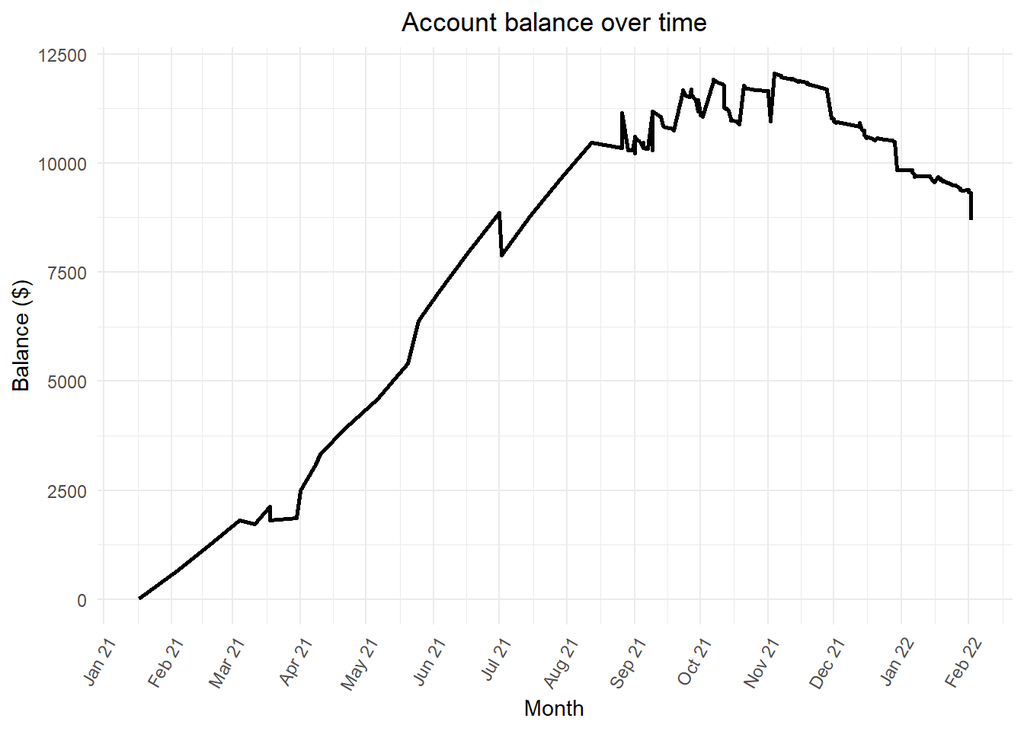

```r
ggplot(new_spending, aes(x = correct_date, y = correct_balance)) + geom_line(size=1) + labs(title = "Account balance over time", x = "Month", y = "Balance ($)") + theme_minimal() + scale_x_date(date_breaks = "1 month", date_labels = "%b %y") + theme(axis.text.x=element_text(angle=60, hjust=1)) + theme(plot.title = element_text(hjust = 0.5))
```

First, I determined the total expenses across all categories to see where the bulk of my transactions were. Negative values indicate that money was spent while positive values indicate money earned. For the majority of 2021, I lived with my parents who financially supported me until late August when I moved out which allowed me to save most of what I made from work.

```r
new_spending %>% group_by(Category) %>% summarize(total_expense = sum(correct_value))
```

```
## # A tibble: 13 x 2
##    Category       total_expense
##    <chr>                  <dbl>
##  1 Beauty                -53
##  2 Clothes              -200.83
##  3 Deposit                25
##  4 Education             -78
##  5 Entertainment        -501.8
##  6 Food                 -234.06
##  7 Groceries           -1067.06
##  8 Housing             -3479.02
##  9 Income              15882.07
## 10 Item                -1175.58
## 11 Medical              -211.16
## 12 Transportation       -223.61
## 13 Verification            0.22
```

```r
new_spending %>% group_by(Category) %>% filter(is_expense == "TRUE") %>% summarize(Amount = abs(sum(correct_value))) %>% mutate(Percentage = (Amount/7224.12)*100)
```

```
## # A tibble: 10 x 3
##    Category        Amount Percentage
##    <chr>            <dbl>      <dbl>
##  1 Beauty           53     0.7336534
##  2 Clothes         200.83  2.779993
##  3 Education        78     1.079716
##  4 Entertainment   501.8   6.946175
##  5 Food            234.06  3.239979
##  6 Groceries      1067.06 14.77080
##  7 Housing        3479.02 48.15839
##  8 Item           1175.58 16.27299
##  9 Medical         211.16  2.922986
## 10 Transportation  223.61  3.095325
```

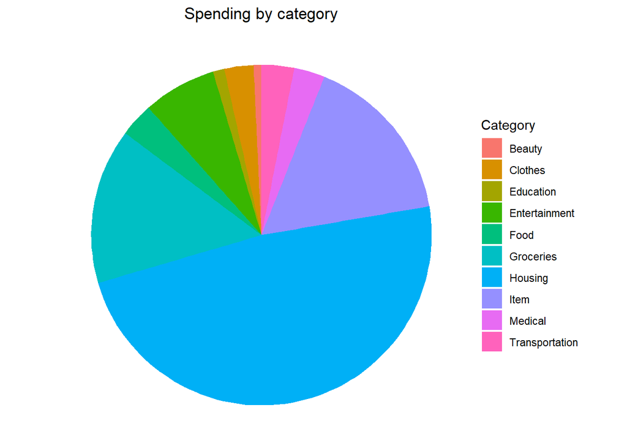

```r
ggplot(spending_percent, aes(x = "", y = Amount, fill = Category)) + geom_bar(stat = "identity", width = 1) + coord_polar("y", start = 0) + theme_void() + labs(title = "Spending by category") + theme(plot.title = element_text(hjust = 0.5))
```

I decided to conduct spending analyses only for the period of time after I moved out and began to financially support myself, roughly 5 months ago. The date time difference function in R makes this easy. This came out to about 160 days or 23 weeks or 5.26 months.

```r
difftime("2022-02-02", "2021-08-26", units = "days")
```

```
## Time difference of 160.0417 days
```

```r
difftime("2022-02-02", "2021-08-26", units = "weeks")
```

```
## Time difference of 22.8631 weeks
```

```r
160.0417/(365/12)
```

```
## [1] 5.261645
```

```r
new_spending %>% group_by(Category) %>% filter(is_expense == "TRUE") %>% filter((month == "Aug" & year == "2021") | (month == "Sep" & year == "2021") | (month == "Oct" & year == "2021") | (month == "Nov" & year == "2021") | (month == "Dec" & year == "2021") | (month == "Jan" & year == "2022") | (month == "Feb" & year == "2022")) %>% summarize(Average_monthly_spending = abs((sum(correct_value)))/5.261622)
```

```
## # A tibble: 10 x 2
##    Category       Average_monthly_spending
##    <chr>                             <dbl>
##  1 Beauty                         10.07294
##  2 Clothes                        38.16884
##  3 Education                      14.82433
##  4 Entertainment                  95.36983
##  5 Food                           44.48438
##  6 Groceries                     202.8006
##  7 Housing                       661.2068
##  8 Item                          204.9159
##  9 Medical                        40.13211
## 10 Transportation                 42.49830
```

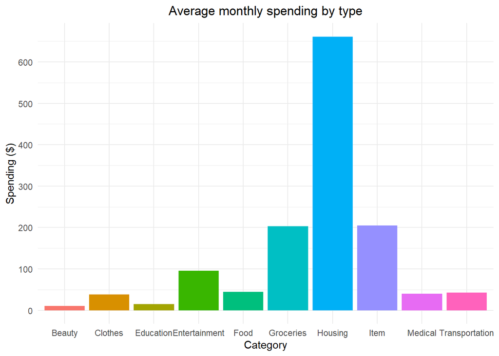

```r
ggplot(data = average_by_month, aes(x = Category, y = Average_monthly_spending, fill = Category)) + geom_bar(stat = "identity", show.legend = FALSE) + theme_minimal() + labs(title = "Average monthly spending by type", x = "Category", y = "Spending ($)") + theme(plot.title = element_text(hjust = 0.5)) + scale_y_continuous(breaks = seq(0, 700, by = 100))
```

Since spending in certain categories can drastically differ between months, I also calculated the *total* spending for each type by the month, illustrated in a line chart showing change over time. At some points of time, I spent more on a certain category than other months such as rent which I was sometimes paying too early or late. I also did not spend money on every category at least once a month, such as for haircuts which I did not get on a regular basis. Only food, groceries, and entertainment expenses appeared relatively consistent over the time period. November, likely due to two rent payments, was the month I spent the most money in comparatively. The numbers used to make this graph are shown in a table below as well.

```r
spending_by_month %>% select(month, Category, total_value) %>% pivot_wider(names_from = month, values_from = total_value, values_fill = 0)
```

```
## # A tibble: 10 x 8
##    Category          Jan    Feb    Aug        Sep    Oct     Nov    Dec
##    <chr>           <dbl>  <dbl>  <dbl>      <dbl>  <dbl>   <dbl>  <dbl>
##  1 Beauty          45      0      0      0          8       0      0
##  2 Clothes         24.39   0      0     43.29      66.79   66.36   0
##  3 Entertainment  118.61  32.47   0     30.81     226.17   38.81 119.87
##  4 Food            13.75   0      0     98.69      31.55   70.07  20
##  5 Groceries      131.96   0     50.45 337.53     194.8   207.67 144.65
##  6 Housing         78.11 665.41 793.64   4.480000  10    1281.55 654.79
##  7 Item             0.89  12.44   0    374.49     609.19    0     81.18
##  8 Medical         70.47  31.78   0      0         51.48   43.45  13.98
##  9 Transportation   0      0      0     52.28      57.86    0    113.47
## 10 Education        0      0      0      0          0      39     39
```

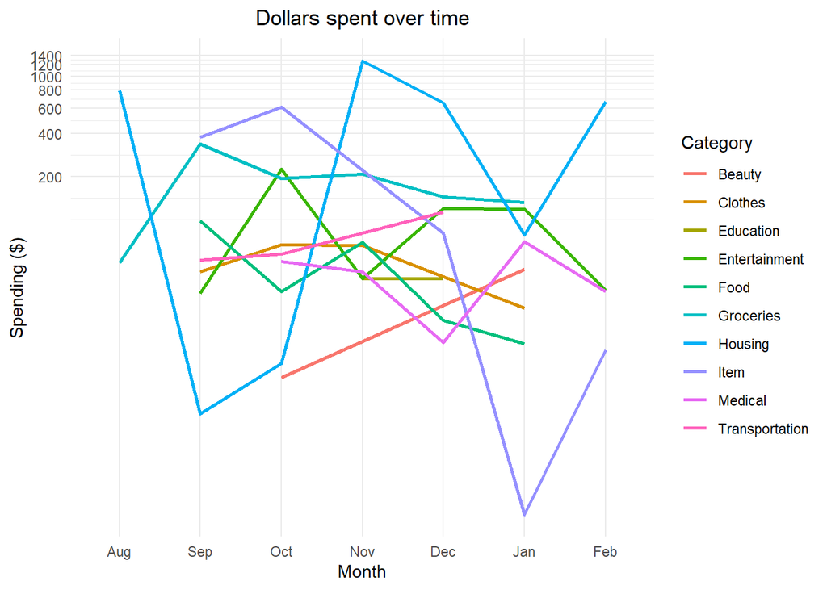

```r
spending_by_month$month <- factor(spending_by_month$month, levels=c("Aug","Sep","Oct","Nov","Dec","Jan","Feb"))
ggplot(spending_by_month, aes(x=month, y=total_value, color=Category, group=Category)) + geom_line(size=1) + theme_minimal() + labs(title = "Dollars spent over time", x = "Month", y = "Spending ($)") + theme(plot.title = element_text(hjust = 0.5)) + scale_y_continuous(breaks = seq(0, 1400, by = 200), trans = "log10")
```

Lastly, I determined *how often* I do each of these activities, whether dining out or shopping for clothes and gifts. The exact frequency I engaged in those activities is printed below as well as a graph showing when those times occurred. In some months, I did a certain activity much more frequently such as grocery runs 9 times in September and December each. Based off of this graph, I can definitely limit how often I do things such as eat out to a more reasonable number and purchase new clothes once a month. After I left my previous job, I spent much more time at home and tended to spend money less often which is visible in the graph.

```r
data.frame(table(new_spending$Category))
```

```
##              Var1 Freq
## 1          Beauty    2
## 2         Clothes    5
## 3         Deposit    3
## 4       Education    2
## 5   Entertainment   17
## 6            Food   13
## 7       Groceries   38
## 8         Housing   17
## 9          Income   23
## 10           Item   20
## 11        Medical    9
## 12 Transportation    6
## 13   Verification    7
```

```r
count_by_month %>% select(month, Category, count) %>% pivot_wider(names_from = month, values_from = count, values_fill = 0)
```

```
## # A tibble: 10 x 8
##    Category         Jan   Feb   Aug   Sep   Oct   Nov   Dec
##    <chr>          <int> <int> <int> <int> <int> <int> <int>
##  1 Beauty             1     0     0     0     1     0     0
##  2 Clothes            1     0     0     1     2     1     0
##  3 Entertainment      5     1     0     2     4     2     3
##  4 Food               2     0     0     4     2     4     1
##  5 Groceries          6     0     1     9     6     7     9
##  6 Housing            1     2     1     6     1     4     2
##  7 Item               3     1     0     5     6     0     2
##  8 Medical            3     1     0     0     2     2     1
##  9 Transportation     0     0     0     2     2     0     2
## 10 Education          0     0     0     0     0     1     1
```

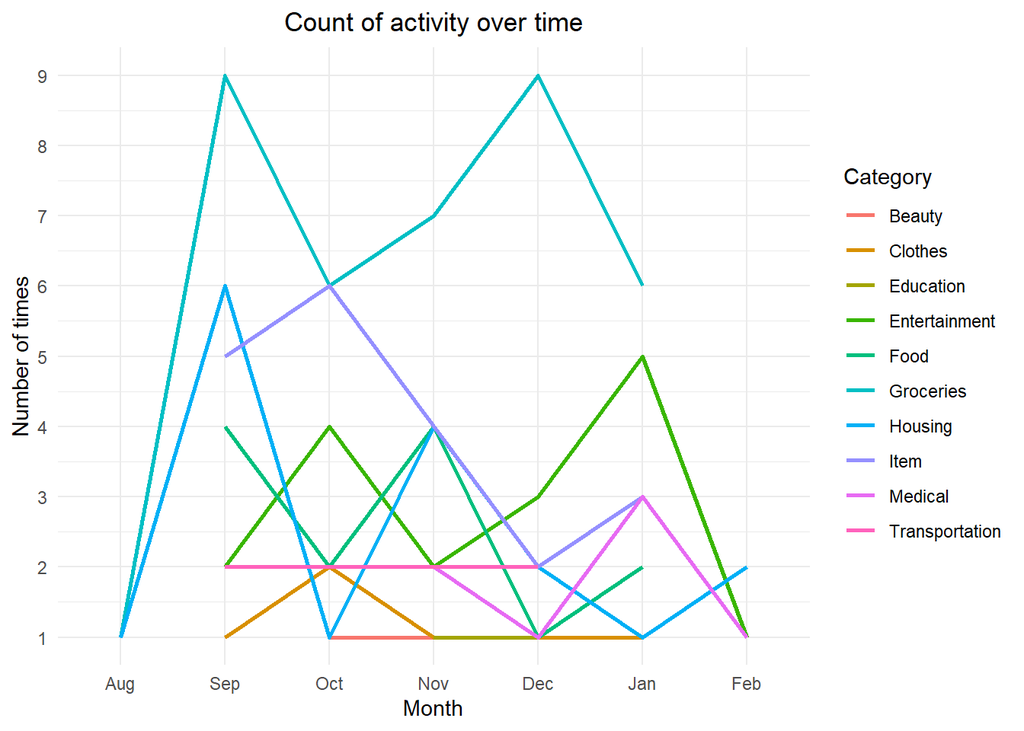

```r
count_by_month$month <- factor(count_by_month$month, levels=c("Aug","Sep","Oct","Nov","Dec","Jan","Feb"))
ggplot(count_by_month, aes(x=month, y=count, color=Category, group=Category)) + geom_line(size=1) + theme_minimal() + labs(title = "Count of activity over time", x = "Month", y = "Number of times") + theme(plot.title = element_text(hjust = 0.5)) + scale_y_continuous(breaks = seq(0, 10, by = 1))
```

## Conclusion

These analyses about my financial activity show me where and how I’m spending my money; although I already consider myself a frugal and prudent person when it comes to finances, it still helps to see areas I can focus on reducing to save money. Necessary expenses such as housing, groceries, medication, and transportation costs will be always prioritized over the luxuries like restaurants, clothes, concert tickets, movies, outings, and video games where I should be more conservative in the future Such luxuries can only be considered after I’ve used my money for necessary expenses and even then I need to ensure any budget I create based off of my existing habits can accommodate for those items. This project gave me insight on my behavior and will definitely inform future spending activity.